# Results

Lukáš ‘hejtmy’ Hejtmánek

10/01/2021

## Rbans

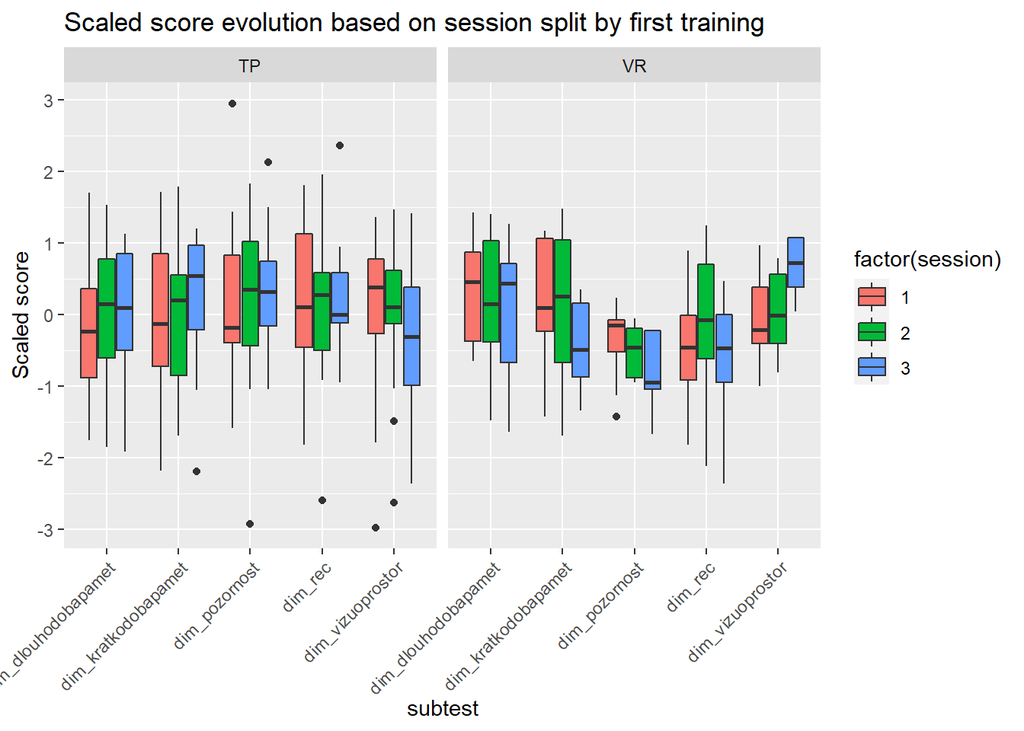

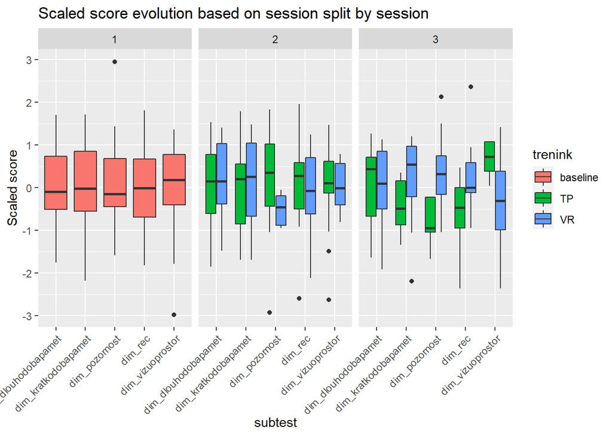

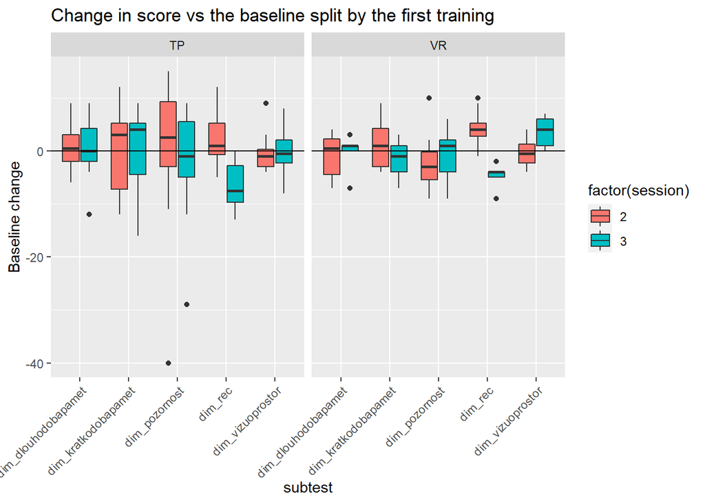

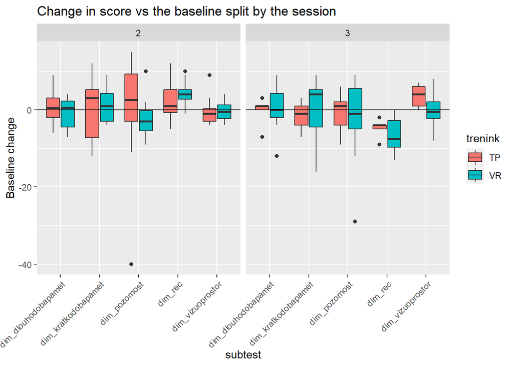

## Supermarket improvement during the 6 weeks

. VR - bylo by možné vzít průměr (1. sezení bylo víc zácvik a někteří dělali test, takže to ukazuje blbosti) 2. a 3 sezení a posledního a předposledního sezení a porovnat je? Myslím si, že tam je u většiny lidí posun, ale třeba o půl nebo jeden bod. Prostě je fakt minimální a potřebují pravděpodobně mnohem intenzivní trénink - liší se ti, co mají méně než 10 sezení od těch, kterí mají 10 a více? Žádné velké predikce bychom se nedělali - nejsou na to data a žádný jasný vztah tam nevidím teda. Očividně blbý efekt vidím u těch, co mega kolísají, Mohli bychom se tak i vyhnout načítání dat z domu (pokud je to prostě fakt těžký), jelikož ta úloha je mnohem složitější a připadá mi težké oddělit ty chyby mezi sebou a budou se míchat dohromady

Improvement in maximum achieved difficulty

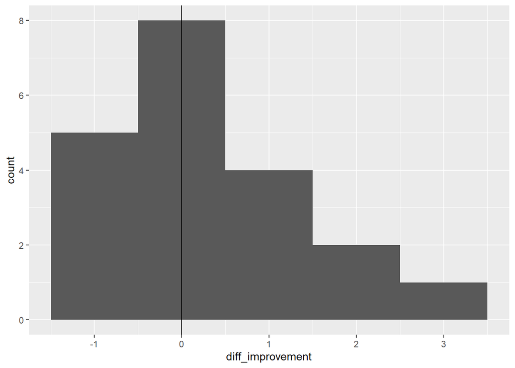

[output not shown]

[output not shown]

```
##
##  Chi-squared test for given probabilities
##
## data:  table(df_remediation_improvement$diff_improvement > 0)
## X-squared = 1.8, df = 1, p-value = 0.1797
```

## adherence and feasibility

- počet absolvovaných VR sezení a jejich délka “jak dlouho u toho vydrželi” a výsledky dotazníků - jak je to bavilo, jestli by si to chtěli zopakovat a jestli jim to připadalo užitečné

```
## # A tibble: 5 x 2
##   n_sessions     n
##        <int> <int>
## 1         12    15
## 2         13     2
## 3         14     1
## 4         16     1
## 5         17     1
```

There is no variability in the number of VR sessions - 17/20 people did 12 or 13 sessions, so there is no point in searching for the effect of number of sessions.

## Mixed model RBANS

```
##           Df  Pillai approx F num Df den Df    Pr(>F)
## session    1 0.69483   17.304      5     38 6.594e-09 ***
## trenink    1 0.07666    0.631      5     38    0.6772
## Residuals 42
## ---
## Signif. codes:  0 '***' 0.001 '**' 0.01 '*' 0.05 '.' 0.1 ' ' 1
```

Predicting IQ celek

```
## Linear mixed model fit by REML. t-tests use Satterthwaite's method [
## lmerModLmerTest]
## Formula: iq_celek ~ trenink + factor(session) + (1 | rbansid)
##    Data: df_rbans_conditions
##
## REML criterion at convergence: 322.5
##
## Scaled residuals:
##      Min       1Q   Median       3Q      Max
## -1.94923 -0.44042  0.08176  0.34258  1.82280
##
## Random effects:
##  Groups   Name        Variance Std.Dev.
##  rbansid  (Intercept) 155.09   12.454
##  Residual              20.76    4.557
## Number of obs: 45, groups:  rbansid, 28
##
## Fixed effects:
##                  Estimate Std. Error     df t value Pr(>|t|)
## (Intercept)        71.997      2.552 30.671  28.213   <2e-16 ***
## treninkVR          -1.488      1.685 15.940  -0.883   0.3901
## factor(session)3   -3.323      1.694 15.618  -1.962   0.0679 .
## ---
## Signif. codes:  0 '***' 0.001 '**' 0.01 '*' 0.05 '.' 0.1 ' ' 1
##
## Correlation of Fixed Effects:
##             (Intr) trnnVR
## treninkVR   -0.189
## fctr(sssn)3 -0.094 -0.410
```

```
## Linear mixed model fit by REML. t-tests use Satterthwaite's method [
## lmerModLmerTest]
## Formula: dim_kratkodobapamet ~ trenink + factor(session) + (1 | rbansid)
##    Data: df_rbans_conditions
##
## REML criterion at convergence: 304.6
##
## Scaled residuals:
##      Min       1Q   Median       3Q      Max
## -1.48461 -0.43747  0.04616  0.46654  1.55749
##
## Random effects:
##  Groups   Name        Variance Std.Dev.
##  rbansid  (Intercept) 81.55    9.030
##  Residual             18.12    4.257
## Number of obs: 45, groups:  rbansid, 28
##
## Fixed effects:
##                  Estimate Std. Error     df t value Pr(>|t|)
## (Intercept)        35.919      1.939 32.798  18.529   <2e-16 ***
## treninkVR           2.158      1.559 16.757   1.384    0.185
## factor(session)3   -1.016      1.572 16.290  -0.646    0.527
## ---
## Signif. codes:  0 '***' 0.001 '**' 0.01 '*' 0.05 '.' 0.1 ' ' 1
##
## Correlation of Fixed Effects:
##             (Intr) trnnVR
## treninkVR   -0.230
## fctr(sssn)3 -0.118 -0.410
```

```
## Linear mixed model fit by REML. t-tests use Satterthwaite's method [
## lmerModLmerTest]
## Formula: dim_dlouhodobapamet ~ trenink + factor(session) + (1 | rbansid)
##    Data: df_rbans_conditions
##
## REML criterion at convergence: 272.7
##
## Scaled residuals:
##      Min       1Q   Median       3Q      Max
## -1.61628 -0.32505 -0.00335  0.43704  1.29162
##
## Random effects:
##  Groups   Name        Variance Std.Dev.
##  rbansid  (Intercept) 52.341   7.235
##  Residual              5.478   2.341
## Number of obs: 45, groups:  rbansid, 28
##
## Fixed effects:
##                  Estimate Std. Error      df t value Pr(>|t|)
## (Intercept)       34.0827     1.4583 30.1548  23.372   <2e-16 ***
## treninkVR         -1.0396     0.8683 15.9821  -1.197    0.249
## factor(session)3   0.1545     0.8722 15.7165   0.177    0.862
## ---
## Signif. codes:  0 '***' 0.001 '**' 0.01 '*' 0.05 '.' 0.1 ' ' 1
##
## Correlation of Fixed Effects:
##             (Intr) trnnVR
## treninkVR   -0.170
## fctr(sssn)3 -0.084 -0.411
```

```
## Linear mixed model fit by REML. t-tests use Satterthwaite's method [
## lmerModLmerTest]
## Formula: dim_pozornost ~ trenink + factor(session) + (1 | rbansid)
##    Data: df_rbans_conditions
##
## REML criterion at convergence: 320.5
##
## Scaled residuals:
##     Min      1Q  Median      3Q     Max
## -1.4080 -0.4620 -0.1840  0.5654  1.6016
##
## Random effects:
##  Groups   Name        Variance Std.Dev.
##  rbansid  (Intercept) 99.89    9.995
##  Residual             32.53    5.703
## Number of obs: 45, groups:  rbansid, 28
##
## Fixed effects:
##                  Estimate Std. Error      df t value Pr(>|t|)
## (Intercept)       41.6911     2.2536 33.8562  18.500   <2e-16 ***
## treninkVR         -0.4187     2.0694 16.1235  -0.202    0.842
## factor(session)3  -1.0908     2.0917 15.5534  -0.522    0.609
## ---
## Signif. codes:  0 '***' 0.001 '**' 0.01 '*' 0.05 '.' 0.1 ' ' 1
##
## Correlation of Fixed Effects:
##             (Intr) trnnVR
## treninkVR   -0.262
## fctr(sssn)3 -0.139 -0.409
```

```
## Linear mixed model fit by REML. t-tests use Satterthwaite's method [
## lmerModLmerTest]
## Formula: dim_rec ~ trenink + factor(session) + (1 | rbansid)
##    Data: df_rbans_conditions
##
## REML criterion at convergence: 231.2
##
## Scaled residuals:
##      Min       1Q   Median       3Q      Max
## -1.80626 -0.33985 -0.02757  0.24407  1.79100
##
## Random effects:
##  Groups   Name        Variance Std.Dev.
##  rbansid  (Intercept) 8.447    2.906
##  Residual             5.373    2.318
## Number of obs: 45, groups:  rbansid, 28
##
## Fixed effects:
##                  Estimate Std. Error      df t value Pr(>|t|)
## (Intercept)       28.7694     0.7410 36.4420  38.826  < 2e-16 ***
## treninkVR          0.1822     0.8243 14.5455   0.221    0.828
## factor(session)3  -8.4736     0.8372 13.8593 -10.121 8.82e-08 ***
## ---
## Signif. codes:  0 '***' 0.001 '**' 0.01 '*' 0.05 '.' 0.1 ' ' 1
##
## Correlation of Fixed Effects:
##             (Intr) trnnVR
## treninkVR   -0.318
## fctr(sssn)3 -0.179 -0.409
```

```
## Linear mixed model fit by REML. t-tests use Satterthwaite's method [
## lmerModLmerTest]
## Formula: dim_vizuoprostor ~ trenink + factor(session) + (1 | rbansid)
##    Data: df_rbans_conditions
##
## REML criterion at convergence: 241.6
##
## Scaled residuals:
##      Min       1Q   Median       3Q      Max
## -2.62690 -0.28170  0.03518  0.64616  1.33185
##
## Random effects:
##  Groups   Name        Variance Std.Dev.
##  rbansid  (Intercept)  4.238   2.059
##  Residual             11.237   3.352
## Number of obs: 45, groups:  rbansid, 28
##
## Fixed effects:
##                  Estimate Std. Error      df t value Pr(>|t|)
## (Intercept)       22.8376     0.8117 41.9799  28.137   <2e-16 ***
## treninkVR         -1.0565     1.1401 18.2087  -0.927   0.3662
## factor(session)3   2.4838     1.1664 17.6312   2.130   0.0476 *
## ---
## Signif. codes:  0 '***' 0.001 '**' 0.01 '*' 0.05 '.' 0.1 ' ' 1
##
## Correlation of Fixed Effects:
##             (Intr) trnnVR
## treninkVR   -0.401
## fctr(sssn)3 -0.260 -0.408
```

## Mixed model random effect predicting the rbans performance with supermarket performance

Modelling the supermarket with mixed effect modelling gives us base trial difficulty of 5.3305082 and improvement of 0.0850267 per session. But it also models individual improvement and base performance. That is in the table below. Some participants have overall better base performance and some simply improve better or worse from this baseline. We can use these metrics to predict the RBANS performance change.

|  | Base performance change | Improvement change |
| --- | --- | --- |
| Ren | 0.6935590 | -0.0899948 |
| lucie | -0.6349279 | -0.0867086 |
| zasuvka | 0.4186284 | -0.0380255 |
| stachova | -0.8269943 | -0.0376266 |
| radim | 1.0904730 | -0.0273535 |
| Lindinek | 1.7295161 | -0.0143848 |
| stones123 | -0.3748227 | -0.0131951 |
| Polter | 0.7632498 | -0.0119641 |
| vaclavcova | 0.0081358 | -0.0112587 |
| pavel | -0.1037491 | -0.0028468 |
| 1986 | 1.2087288 | -0.0008559 |
| bohdan | -0.4378765 | 0.0112744 |
| zuzka | -0.0958839 | 0.0114409 |
| banyasz petr | -1.7757294 | 0.0277408 |
| 1870 | -1.4994927 | 0.0280838 |
| Tom1 | -0.6724457 | 0.0319971 |
| nowak | -1.9778265 | 0.0445290 |
| andrejka | 1.7775383 | 0.0479655 |
| tomas.uhlir.17 | 0.9480993 | 0.0620024 |
| hanousek | -0.2381798 | 0.0691803 |

These results are kinda challenging to explain and I am not sure if they are correct :D But the thing is … when modelling the supermarket performance as an effect of session, we get those individual “intercepts” (basically default skill) and “session_slope” (rate of change - some people learn faster than others) - viz paragraph above. I then use these individual estimates to predict rbans score! Therefore predicting RBANS standardized scores by the “default” skill in supermarket and the “rate of improvement in supermarket” and also the session(arguably participants doing the VR in 2nd iteration should be generally better than those doing it in the 1st). Below are the results for individual rbans scales (those are scaled per session (B has different scaling than C))

```
##
## Call:
## glm(formula = dim_dlouhodobapamet ~ intercept + session_slope +
##     factor(session), data = df_rbans_randcoef_wide_zscore)
##
## Deviance Residuals:
##     Min       1Q   Median       3Q      Max
## -1.7183  -0.4505  -0.1928   0.3835   1.5739
##
## Coefficients:
##                  Estimate Std. Error t value Pr(>|t|)
## (Intercept)        0.2175     0.3588   0.606   0.5540
## intercept          0.5003     0.2045   2.447   0.0282 *
## session_slope      0.6473     4.7553   0.136   0.8937
## factor(session)3  -0.3597     0.4508  -0.798   0.4383
## ---
## Signif. codes:  0 '***' 0.001 '**' 0.01 '*' 0.05 '.' 0.1 ' ' 1
##
## (Dispersion parameter for gaussian family taken to be 0.7409818)
##
##     Null deviance: 14.890  on 17  degrees of freedom
## Residual deviance: 10.374  on 14  degrees of freedom
## AIC: 51.162
##
## Number of Fisher Scoring iterations: 2
```

```
##
## Call:
## glm(formula = dim_kratkodobapamet ~ intercept + session_slope +
##     factor(session), data = df_rbans_randcoef_wide_zscore)
##
## Deviance Residuals:
##      Min        1Q    Median        3Q       Max
## -2.14286  -0.52297   0.04142   0.64047   1.16220
##
## Coefficients:
##                  Estimate Std. Error t value Pr(>|t|)
## (Intercept)       0.07032    0.41257   0.170   0.8671
## intercept         0.57723    0.23511   2.455   0.0278 *
## session_slope    -1.17578    5.46835  -0.215   0.8329
## factor(session)3 -0.05607    0.51842  -0.108   0.9154
## ---
## Signif. codes:  0 '***' 0.001 '**' 0.01 '*' 0.05 '.' 0.1 ' ' 1
##
## (Dispersion parameter for gaussian family taken to be 0.9798732)
##
##     Null deviance: 19.977  on 17  degrees of freedom
## Residual deviance: 13.718  on 14  degrees of freedom
## AIC: 56.192
##
## Number of Fisher Scoring iterations: 2
```

```
##
## Call:
## glm(formula = dim_rec ~ intercept + session_slope + factor(session),
##     data = df_rbans_randcoef_wide_zscore)
##
## Deviance Residuals:
##     Min       1Q   Median       3Q      Max
## -2.0915  -0.5874  -0.1126   0.5970   1.8917
##
## Coefficients:
##                   Estimate Std. Error t value Pr(>|t|)
## (Intercept)      -0.003943   0.442928  -0.009    0.993
## intercept        -0.136955   0.252408  -0.543    0.596
## session_slope     1.560114   5.870669   0.266    0.794
## factor(session)3  0.328734   0.556565   0.591    0.564
##
## (Dispersion parameter for gaussian family taken to be 1.12936)
##
##     Null deviance: 16.460  on 17  degrees of freedom
## Residual deviance: 15.811  on 14  degrees of freedom
## AIC: 58.748
##
## Number of Fisher Scoring iterations: 2
```

```
##
## Call:
## glm(formula = dim_pozornost ~ intercept + session_slope + factor(session),
##     data = df_rbans_randcoef_wide_zscore)
##
## Deviance Residuals:
##      Min        1Q    Median        3Q       Max
## -1.24716  -0.27067   0.07406   0.37138   1.12269
##
## Coefficients:
##                  Estimate Std. Error t value Pr(>|t|)
## (Intercept)       -0.4222     0.3124  -1.351   0.1981
## intercept          0.3783     0.1780   2.125   0.0519 .
## session_slope      1.7429     4.1411   0.421   0.6802
## factor(session)3   0.6746     0.3926   1.718   0.1078
## ---
## Signif. codes:  0 '***' 0.001 '**' 0.01 '*' 0.05 '.' 0.1 ' ' 1
##
## (Dispersion parameter for gaussian family taken to be 0.561935)
##
##     Null deviance: 13.0965  on 17  degrees of freedom
## Residual deviance:  7.8671  on 14  degrees of freedom
## AIC: 46.183
##
## Number of Fisher Scoring iterations: 2
```

```
##
## Call:
## glm(formula = dim_vizuoprostor ~ intercept + session_slope +
##     factor(session), data = df_rbans_randcoef_wide_zscore)
##
## Deviance Residuals:
##      Min        1Q    Median        3Q       Max
## -1.48343  -0.42724  -0.09437   0.43363   1.72163
##
## Coefficients:
##                  Estimate Std. Error t value Pr(>|t|)
## (Intercept)       -0.0275     0.3948  -0.070    0.945
## intercept          0.2416     0.2250   1.074    0.301
## session_slope      4.8881     5.2332   0.934    0.366
## factor(session)3  -0.2745     0.4961  -0.553    0.589
##
## (Dispersion parameter for gaussian family taken to be 0.8974123)
##
##     Null deviance: 14.563  on 17  degrees of freedom
## Residual deviance: 12.564  on 14  degrees of freedom
## AIC: 54.61
##
## Number of Fisher Scoring iterations: 2
```

What we can see is that the base individual performance (and although it SOUNDS like BASELINE, it really is not for some participants, especially if intercept is correlated with slope - which in our case is at r=0.31) predicts RBANS score for short and long term memory!!! The better the participants do in supermarket, the better they do in the following RBANS.

WARNING WARNING WARNING!!!! I am absolutely NOT SURE I can do it this way :D it just occured to me and it beautifully corresponds to what we might expect happening, so there you go. But I’ll ponder of the matter of affairs a bit longer. Also, it does NOT take into consideration the rbans baseline! E.g. there is certainly some cross correlation - people who do well in RBANS do well in supermarket as well. Personally I believe that is the case, rather than supermarket actually changing something. I tried to run the model on baseline changes, but it is generally non significant for those valid scales and becomes significant for the OTHER scales. BUT the issue is with the generally incomparability of the RBANS A-B-C versions, and therefore we dunno if the A-C decrease of 2 points in long term memory is actually INCREASE in performance, as C is so much more challenging. That would require complete rescaling of RBANS and we DO NOT have enough peeps to do so.